# Lab 11

STAT 359 Data Visualization

# Overview

This lab is intended to begin combining all lessons learned in previous labs. You should have read through Chapter 11 by this point.

# Datasets

The `degrees-that-pay-back.csv`, `salaries-by-college-type.csv`, `salaries-by-region.csv` files are from Kaggle (https://www.kaggle.com/wsj/college-salaries).

Please see the website for the data dictionary and high level descriptions of the data.

# Task

Run the provided R code, just below, prior to completing the tasks.

Note: Appropriate styling and labeling is REQUIRED (where APPROPRIATE… remember, this is subjective).

```r
# Import libraries
library(tidyverse)
library(ggthemes)

# Import data
degree_data <- read_csv('degrees-that-pay-back.csv') %>%
  mutate(`Starting Median Salary` = as.double(str_replace_all(`Starting Median Salary`, "[\\$\\,]", "")),
         `Mid-Career Median Salary` = as.double(str_replace_all(`Mid-Career Median Salary`, "[\\$\\,]", "")),
         `Mid-Career 10th Percentile Salary` = as.double(str_replace_all(`Mid-Career 10th Percentile Salary`, "[\\$\\,]", "")),
         `Mid-Career 25th Percentile Salary` = as.double(str_replace_all(`Mid-Career 25th Percentile Salary`, "[\\$\\,]", "")),
         `Mid-Career 75th Percentile Salary` = as.double(str_replace_all(`Mid-Career 75th Percentile Salary`, "[\\$\\,]", "")),
         `Mid-Career 90th Percentile Salary` = as.double(str_replace_all(`Mid-Career 90th Percentile Salary`, "[\\$\\,]", "")),
         PercentChangeBin = case_when(`Percent change from Starting to Mid-Career Salary` < 25 ~ '< 25%',
                                      `Percent change from Starting to Mid-Career Salary` >= 25 & `Percent change from Starting to Mid-Career Salary` < 50 ~ '25% - 75%',
                                      `Percent change from Starting to Mid-Career Salary` >= 50 & `Percent change from Starting to Mid-Career Salary` < 75 ~ '50% - 75%',
                                      `Percent change from Starting to Mid-Career Salary` >= 75 ~ '75% +'))

dim(degree_data)
```

```
## [1] 50  9
```

```r
glimpse(degree_data)
```

```
## Observations: 50
## Variables: 9
## $ `Undergraduate Major`                               <chr> "Accountin...
## $ `Starting Median Salary`                            <dbl> 46000, 577...
## $ `Mid-Career Median Salary`                          <dbl> 77100, 101...
## $ `Percent change from Starting to Mid-Career Salary` <dbl> 67.6, 75.0...
## $ `Mid-Career 10th Percentile Salary`                 <dbl> 42200, 643...
## $ `Mid-Career 25th Percentile Salary`                 <dbl> 56100, 821...
## $ `Mid-Career 75th Percentile Salary`                 <dbl> 108000, 12...
## $ `Mid-Career 90th Percentile Salary`                 <dbl> 152000, 16...
## $ PercentChangeBin                                    <chr> "50% - 75%...
```

```r
college_type_data <- read_csv('salaries-by-college-type.csv', na = "N/A") %>%
  mutate(`Starting Median Salary` = as.double(str_replace_all(`Starting Median Salary`, "[\\$\\,]", "")),
         `Mid-Career Median Salary` = as.double(str_replace_all(`Mid-Career Median Salary`, "[\\$\\,]", "")),
         `Mid-Career 10th Percentile Salary` = as.double(str_replace_all(`Mid-Career 10th Percentile Salary`, "[\\$\\,]", "")),
         `Mid-Career 25th Percentile Salary` = as.double(str_replace_all(`Mid-Career 25th Percentile Salary`, "[\\$\\,]", "")),
         `Mid-Career 75th Percentile Salary` = as.double(str_replace_all(`Mid-Career 75th Percentile Salary`, "[\\$\\,]", "")),
         `Mid-Career 90th Percentile Salary` = as.double(str_replace_all(`Mid-Career 90th Percentile Salary`, "[\\$\\,]", "")))

dim(college_type_data)
```

```
## [1] 269   8
```

```r
glimpse(college_type_data)
```

```
## Observations: 269
## Variables: 8
## $ `School Name`                       <chr> "Massachusetts Institute o...
## $ `School Type`                       <chr> "Engineering", "Engineerin...
## $ `Starting Median Salary`            <dbl> 72200, 75500, 71800, 62400...
## $ `Mid-Career Median Salary`          <dbl> 126000, 123000, 122000, 11...
## $ `Mid-Career 10th Percentile Salary` <dbl> 76800, NA, NA, 66800, NA, ...
## $ `Mid-Career 25th Percentile Salary` <dbl> 99200, 104000, 96000, 9430...
## $ `Mid-Career 75th Percentile Salary` <dbl> 168000, 161000, 180000, 14...
## $ `Mid-Career 90th Percentile Salary` <dbl> 220000, NA, NA, 190000, NA...
```

```r
region_data <- read_csv('salaries-by-region.csv', na = "N/A") %>%
  mutate(`Starting Median Salary` = as.double(str_replace_all(`Starting Median Salary`, "[\\$\\,]", "")),
         `Mid-Career Median Salary` = as.double(str_replace_all(`Mid-Career Median Salary`, "[\\$\\,]", "")),
         `Mid-Career 10th Percentile Salary` = as.double(str_replace_all(`Mid-Career 10th Percentile Salary`, "[\\$\\,]", "")),
         `Mid-Career 25th Percentile Salary` = as.double(str_replace_all(`Mid-Career 25th Percentile Salary`, "[\\$\\,]", "")),
         `Mid-Career 75th Percentile Salary` = as.double(str_replace_all(`Mid-Career 75th Percentile Salary`, "[\\$\\,]", "")),
         `Mid-Career 90th Percentile Salary` = as.double(str_replace_all(`Mid-Career 90th Percentile Salary`, "[\\$\\,]", "")))

dim(region_data)
```

```
## [1] 320   8
```

```r
glimpse(region_data)
```

```
## Observations: 320
## Variables: 8
## $ `School Name`                       <chr> "Stanford University", "Ca...
## $ Region                              <chr> "California", "California"...
## $ `Starting Median Salary`            <dbl> 70400, 75500, 71800, 59900...
## $ `Mid-Career Median Salary`          <dbl> 129000, 123000, 122000, 11...
## $ `Mid-Career 10th Percentile Salary` <dbl> 68400, NA, NA, 59500, NA, ...
## $ `Mid-Career 25th Percentile Salary` <dbl> 93100, 104000, 96000, 8100...
## $ `Mid-Career 75th Percentile Salary` <dbl> 184000, 161000, 180000, 14...
## $ `Mid-Career 90th Percentile Salary` <dbl> 257000, NA, NA, 201000, NA...
```

0a. Use the `rename()` function to rename the `Mid-Career 90th Percentile Salary` variable in the `degree_data` data to `My Future Salary`

```r
degree_data %>%
  rename('My Future Salary' = `Mid-Career 90th Percentile Salary`) %>%
  names()
```

```
## [1] "Undergraduate Major"
## [2] "Starting Median Salary"
## [3] "Mid-Career Median Salary"
## [4] "Percent change from Starting to Mid-Career Salary"
## [5] "Mid-Career 10th Percentile Salary"
## [6] "Mid-Career 25th Percentile Salary"
## [7] "Mid-Career 75th Percentile Salary"
## [8] "My Future Salary"
## [9] "PercentChangeBin"
```

0b. Create a data frame using the `degree_data` data with the following characteristics:

1. Changes the `Percent change from Starting to Mid-Career Salary` variable to an integer
2. Only contains observations with a starting salary greater than $50,000, but with a percent change less than 75% from the starting to mid-career salary.
3. Only contains the variables: `Undergraduate Major`, `Mid-Career Median Salary`, `Percent change from Starting to Mid-Career Salary`
4. Displays values in descending order from highest `Mid-Career Median Salary` to lowest.

```r
(test <- degree_data %>%
  mutate(`Percent change from Starting to Mid-Career Salary` = as.integer(`Percent change from Starting to Mid-Career Salary`)) %>%
  filter(`Starting Median Salary` > 50000 & PercentChangeBin != '75% +') %>%
  select(`Undergraduate Major`, `Mid-Career Median Salary`,`Percent change from Starting to Mid-Career Salary`) %>%
  arrange(desc(`Mid-Career Median Salary`)))
```

```
## # A tibble: 10 x 3
##    `Undergraduate Maj… `Mid-Career Median … `Percent change from Starting…
##    <chr>                              <dbl>                          <int>
##  1 Chemical Engineeri…               107000                             69
##  2 Computer Engineeri…               105000                             71
##  3 Electrical Enginee…               103000                             69
##  4 Computer Science                   95500                             70
##  5 Industrial Enginee…                94700                             64
##  6 Mechanical Enginee…                93600                             61
##  7 Physician Assistant                91700                             23
##  8 Civil Engineering                  90500                             67
##  9 Construction                       88900                             65
## 10 Nursing                            67000                             23
```

1a. Add a column to the `region_data` dataframe called `isNorthwestern` which contains a value of 1 for Northwestern and a 0 for all other Universities and another column called `isMidwest` which contains a value of 1 for midwest and a 0 for all other regions.

(Note: you will need to find the exact values for “Northwestern” and the “midwest” on your own. hint: use unique() or View())

```r
unique(region_data$Region)
```

```
## [1] "California"   "Western"      "Midwestern"   "Southern"
## [5] "Northeastern"
```

```r
unique(filter(region_data, str_detect(`School Name`, 'Northwestern'))$`School Name`)
```

```
## [1] "Northwestern University"
```

```r
region_data <- region_data %>%
  mutate(isMidwest = ifelse(str_detect(Region, "Midwestern") == TRUE, 1, 0),
         isNorthwestern = ifelse(str_detect(`School Name`, "Northwestern University") == TRUE, 1, 0))
```

1b. Recreate this visualization.

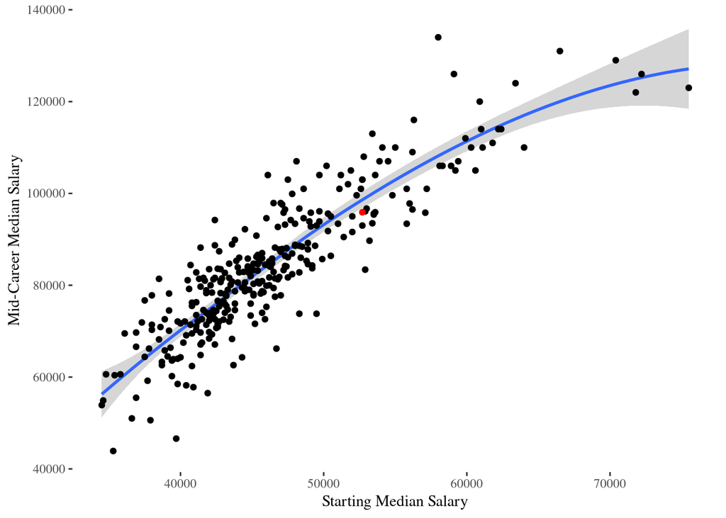

```r
ggplot(region_data, aes(`Starting Median Salary`, `Mid-Career Median Salary`, label = `School Name`)) +
  geom_smooth() +
  geom_point(data = filter(region_data, isNorthwestern == 0), aes(`Starting Median Salary`, `Mid-Career Median Salary`, label = `School Name`)) +
  geom_point(data = filter(region_data, isNorthwestern == 1), aes(`Starting Median Salary`, `Mid-Career Median Salary`, label = `School Name`), color = 'red') +
  theme_tufte()
```

1c. Recreate this visualization.

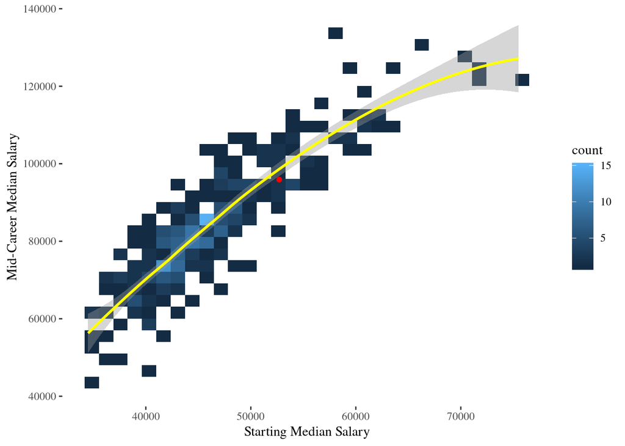

```r
ggplot(region_data, aes(`Starting Median Salary`, `Mid-Career Median Salary`, label = `School Name`)) +
  geom_bin2d(data = filter(region_data, isNorthwestern == 0), aes(`Starting Median Salary`, `Mid-Career Median Salary`)) +
  geom_point(data = filter(region_data, isNorthwestern == 1), aes(`Starting Median Salary`, `Mid-Career Median Salary`, label = `School Name`), color = 'red') +
  geom_smooth(color = 'yellow') +
  theme_tufte()
```

`Both actually do a good job of providing insight into the density of observations. In this particular case it appears that the geom_point is slightly easier on the eyes. However, if more data was involved, geom_bin2d() may be preferred.`

2a. Create a dataset called `region_data2` using the `region_data` which removes `NA` values from the `Region` column and only contains the `Region` and `School Name` variables.

```r
region_data2 <- filter(region_data, !is.na(Region))
region_data2 <- select(region_data2, `School Name`, Region)

#OR

region_data2 <- region_data %>%
  filter(!is.na(Region)) %>%
  select(`School Name`, Region)
```

2b. Create a dataset called `college_type_data2` using the `college_type_data` which removes `NA` from the `School Type` column.

```r
college_type_data2 <- filter(college_type_data, !is.na(`School Type`))
```

2c. Execute the below code and recreate the below visualization using `combined_data`. (hint: theme is dark)

```r
combined_data <- left_join(college_type_data2,
                           region_data2,
                           by = c('School Name'))
```

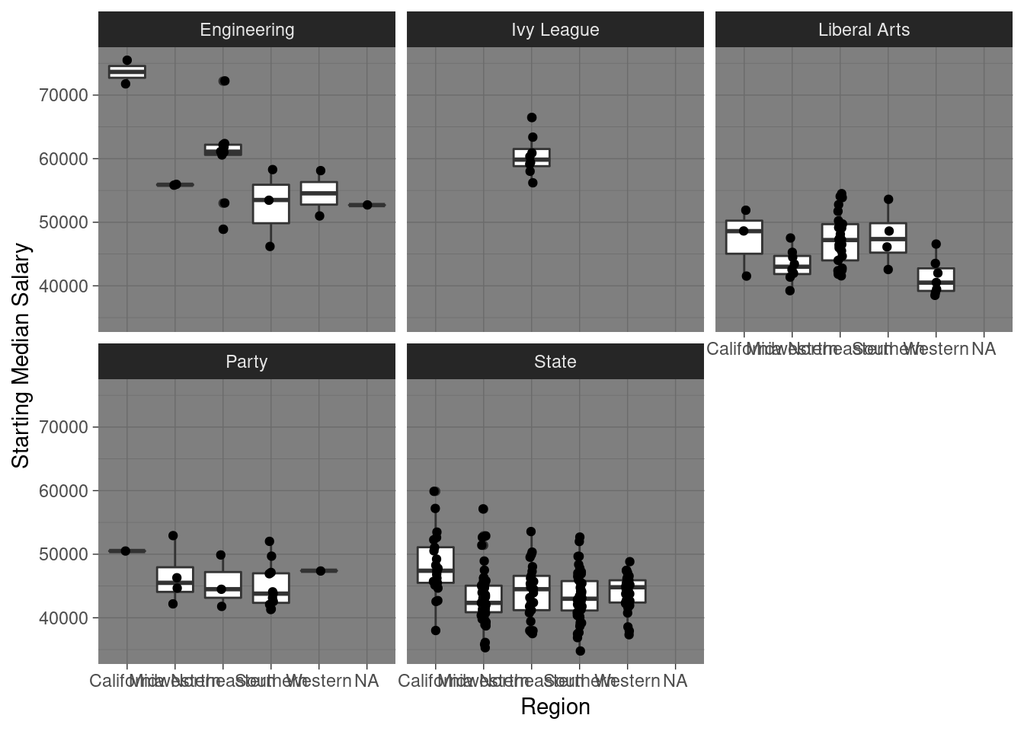

```r
ggplot(combined_data, aes(Region, `Starting Median Salary`)) +
  geom_boxplot() +
  geom_jitter(width = 0.05) +
  facet_wrap(~ `School Type`) +
  theme_dark()
```

2d. Recreate the below visualization and table. (hint: theme is minimal)

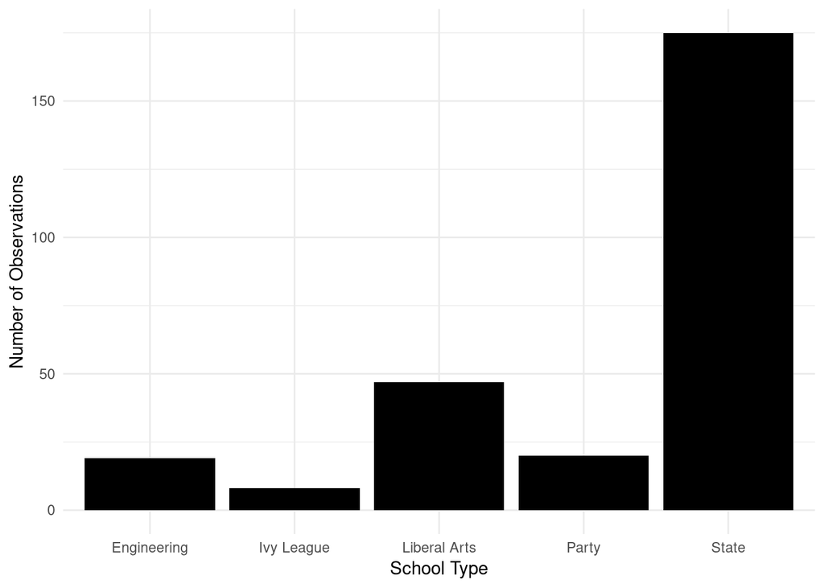

```r
ggplot(combined_data, aes(`School Type`)) +
  geom_bar(fill = 'black') +
  labs(y = "Number of Observations") +
  theme_minimal()
```

```r
combined_data %>%
  group_by(`School Type`) %>%
  summarise('Number of Observations' = n())
```

```
## # A tibble: 5 x 2
##   `School Type` `Number of Observations`
##   <chr>                            <int>
## 1 Engineering                         19
## 2 Ivy League                           8
## 3 Liberal Arts                        47
## 4 Party                               20
## 5 State                              175
```

3a. Recreate the below visualization.

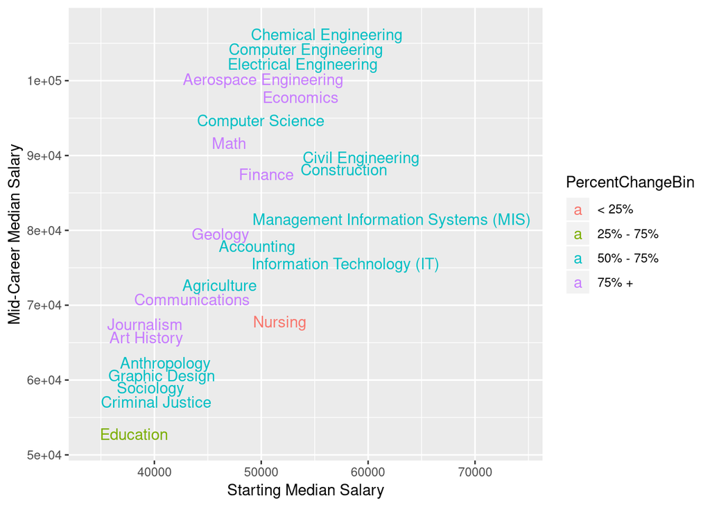

```r
ggplot(degree_data, aes(`Starting Median Salary`, `Mid-Career Median Salary`,
                        label = `Undergraduate Major`,
                        color = PercentChangeBin)) +
  geom_text(check_overlap = TRUE, vjust = 'inward', hjust = 'inward')
```